# Some linear models - part 3

Søren Højsgaard

2024-10-04

Packages used:

```r
library(ggplot2)
library(broom)
library(dplyr)
library(modelr)
library(doBy)
library(ggcorrplot)
```

# 1 Model selection

A model selection method consists of two components:

1. A criterion for choosing one model over another
2. A strategy for moving through possible candidate models (searching all possible models is usually impossible)

# 1.1 The curse of dimensionality

Previously, we specified a set of candidate models to choose among.

Very often, we have a family of models to choose among. Example: Multiple regression with $p$ possible explanatory variables $x_1,\dots, x_p$.

This is a very large family:

Either a predictor is included in the model - or it is not. This gives a total of $2^p$ models to consider:

```r
c(2^6, 2^16, 2^24, 2^31)
```

```
## [1] 6.40e+01 6.55e+04 1.68e+07 2.15e+09
```

```r
c(2^choose(6, 2), 2^choose(16, 2), 2^choose(24, 2), 2^choose(31, 2))
```

```
## [1]  3.28e+04  1.33e+36  1.21e+83 9.53e+139
```

The number $2^\choose(24, 2)$ is in the vicinity of the estimated number of atoms in the universe.

# 1.2 A pragmatic strategy

Use AIC as selection criterion

Search in model space in stepwise way, e.g.:

- Start with large model; remove terms trying to minimize AIC
- Start with small model; add terms trying to minimize AIC
- Start with some model; alternated between removing and adding terms trying to minimize AIC

Note:

- In all cases we typically get local minimum of AIC
- Models are often more or less meaningless when it comes to interpretation - but they may produce good predictions.

# 2 Example - carcass data

Task: predict lean meat percentage from measurements of physical characteristics of pigs.

There are two datasets: `carcass` and `carcassall`. The latter contains more variables.

First we look at the `carcass` dataset.

```r
dat <- doBy::carcass
dat |> head()
```

```
##   Fat11 Meat11 Fat12 Meat12 Fat13 Meat13 LeanMeat
## 1    17     51    12     51    12     61     56.5
## 2    17     49    15     48    15     54     57.6
## 3    14     38    11     34    11     40     55.9
## 4    17     58    12     58    11     58     61.8
## 5    14     51    12     48    13     54     63.0
## 6    20     40    14     40    14     45     54.6
```

```r
dat |> dim()
```

```
## [1] 344   7
```

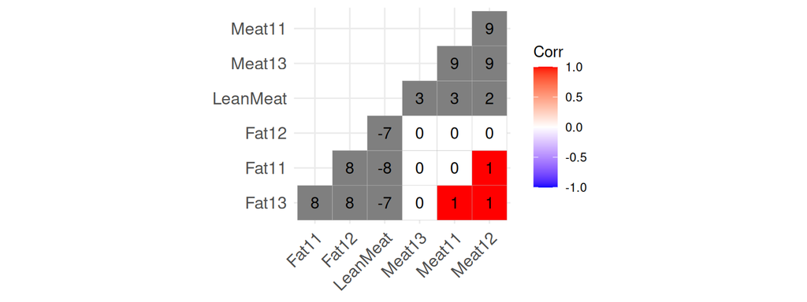

```r
round(10*cor(dat)) |> ggcorrplot(, hc.order = TRUE, type = "lower", lab = TRUE)
```

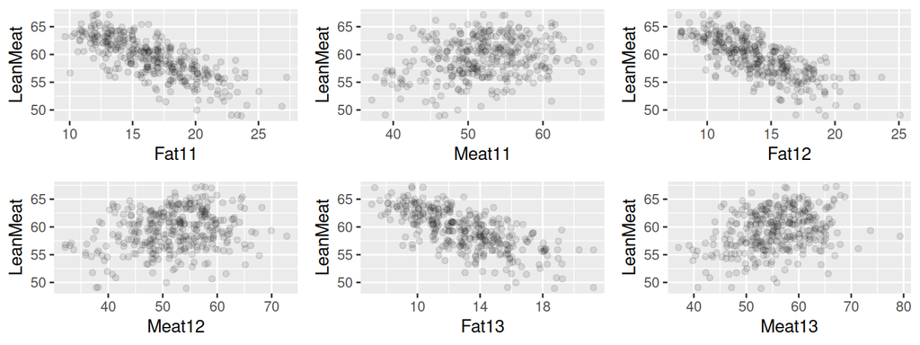

```r
dat |> response_plot(LeanMeat ~ ., data = _, geoms = c(geom_jitter(alpha=.1, w=.1)))
```

Do a principal component analysis to see lower dimensional features

```r
pr <- prcomp(select(dat, -LeanMeat), center=T, scale=T)
summary(pr)
```

```
## Importance of components:
##                          PC1   PC2    PC3   PC4    PC5    PC6
## Standard deviation     1.686 1.607 0.4400 0.417 0.3561 0.2859
## Proportion of Variance 0.474 0.430 0.0323 0.029 0.0211 0.0136
## Cumulative Proportion  0.474 0.904 0.9363 0.965 0.9864 1.0000
```

```r
cor(dat |> select(-LeanMeat), pr$x[,1:4])
```

```
##           PC1    PC2     PC3     PC4
## Fat11  -0.546  0.768  0.3016  0.0500
## Meat11 -0.809 -0.501 -0.1622  0.0322
## Fat12  -0.528  0.783 -0.0982 -0.3011
## Meat12 -0.819 -0.507  0.1584  0.0718
## Fat13  -0.596  0.728 -0.2035  0.2416
## Meat13 -0.765 -0.583  0.0128 -0.1270
```

```r
cor(dat |> select(LeanMeat), pr$x)
```

```
##            PC1    PC2     PC3    PC4     PC5     PC6
## LeanMeat 0.204 -0.812 -0.0634 0.0126 -0.0204 0.00549
```

Focus on full dataset

```r
dat <- doBy::carcassall |> select(-slhouse)
```

```r
set.seed(2024)
i <- sample(nrow(dat), size=0.1*nrow(dat))
train <- dat[i,]
test <- dat[-i,]
```

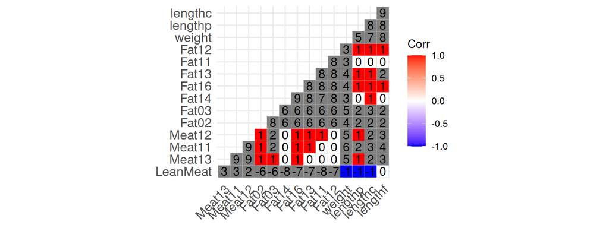

```r
dat_num <- dat |> select_if(is.numeric)
round(10*cor(dat_num)) |> ggcorrplot(, hc.order = TRUE, type = "lower", lab = TRUE)
```

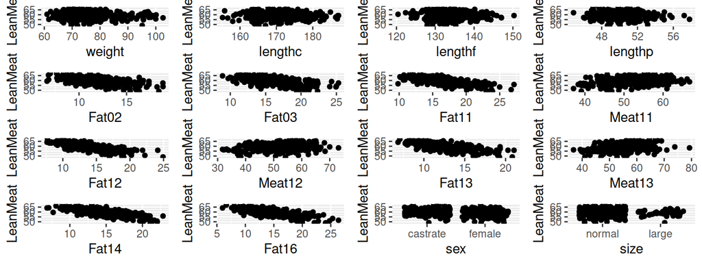

```r
pp <- dat |> response_plot(LeanMeat ~ ., geoms = c(geom_jitter()))
```

```r
lm_full <- lm(LeanMeat ~ ., data = train)
lm_1 <- lm(LeanMeat ~ 1, data = train)
```

```r
lm_full |> AIC()
```

```
## [1] 140
```

```r
lm_1 |> AIC()
```

```
## [1] 187
```

```r
lm_forw <- step(lm_1, direction="forward", scope=terms(lm_full), trace=0)
lm_back <- step(lm_full, direction="backward", trace=0)
lm_both <- step(lm_1, direction="both", scope=terms(lm_full), trace=0)
```

```r
model_list <- list(lm_1=lm_1, lm_forw=lm_forw, lm_both=lm_both, lm_back=lm_back, lm_full=lm_full)
model_list |> sapply(AIC)
```

```
##    lm_1 lm_forw lm_both lm_back lm_full
##     187     133     131     126     140
```

```r
model_list |> sapply(function(x) rmse(x, train))
```

```
##    lm_1 lm_forw lm_both lm_back lm_full
##    3.59    1.34    1.35    1.15    1.11
```

```r
model_list |> sapply(function(x) rmse(x, test))
```

```
##    lm_1 lm_forw lm_both lm_back lm_full
##    3.64    2.22    2.22    2.22    2.26
```